# S. Florida COVID-19 Trajectory

Gabriel J. Odom, PhD, ThD

6/8/2020

# Overview

Analyse Daily COVID-19 Trajectory

```r
library(tidyverse)
library(lubridate)
```

## Testing Data

```r
sflCases_df <- read_csv(
    file = "../../data/FLDH_COVID19_cases_20200607.csv"
)
```

```r
knitr::kable(sflCases_df)
```

| Date | Positive | Negative | PropPositive |
| --- | --- | --- | --- |
| 2-Apr | 544 | 2413 | 0.1839702 |
| 3-Apr | 625 | 1878 | 0.2497004 |
| 4-Apr | 531 | 2521 | 0.1739843 |
| 5-Apr | 311 | 1260 | 0.1979631 |
| 6-Apr | 556 | 2309 | 0.1940663 |
| 7-Apr | 493 | 1990 | 0.1985501 |
| 8-Apr | 488 | 1113 | 0.3048095 |
| 9-Apr | 435 | 2636 | 0.1416477 |
| 10-Apr | 542 | 2505 | 0.1778799 |
| 11-Apr | 563 | 2732 | 0.1708649 |
| 12-Apr | 364 | 1614 | 0.1840243 |
| 13-Apr | 477 | 2267 | 0.1738338 |
| 14-Apr | 364 | 1663 | 0.1795757 |
| 15-Apr | 438 | 2392 | 0.1547703 |
| 16-Apr | 536 | 2767 | 0.1622767 |
| 17-Apr | 519 | 2901 | 0.1517544 |
| 18-Apr | 296 | 1509 | 0.1639889 |
| 19-Apr | 465 | 2690 | 0.1473851 |
| 20-Apr | 413 | 3232 | 0.1133059 |
| 21-Apr | 577 | 4230 | 0.1200333 |
| 22-Apr | 465 | 2701 | 0.1468730 |
| 23-Apr | 619 | 3647 | 0.1451008 |
| 24-Apr | 552 | 2852 | 0.1621622 |
| 25-Apr | 564 | 4136 | 0.1200000 |
| 26-Apr | 384 | 2576 | 0.1297297 |
| 27-Apr | 446 | 2789 | 0.1378671 |
| 28-Apr | 213 | 1333 | 0.1377749 |
| 29-Apr | 309 | 1704 | 0.1535022 |
| 30-Apr | 333 | 3724 | 0.0820804 |
| 1-May | 250 | 3616 | 0.0646663 |
| 2-May | 144 | 2183 | 0.0618823 |
| 3-May | 295 | 2896 | 0.0924475 |
| 4-May | 151 | 3900 | 0.0372747 |
| 5-May | 165 | 2231 | 0.0688648 |
| 6-May | 153 | 2296 | 0.0624745 |
| 7-May | 95 | 2091 | 0.0434584 |
| 8-May | 165 | 2615 | 0.0593525 |
| 9-May | 225 | 2208 | 0.0924784 |
| 10-May | 159 | 2546 | 0.0587800 |
| 11-May | 164 | 3420 | 0.0457589 |
| 12-May | 153 | 1660 | 0.0843905 |
| 13-May | 274 | 2214 | 0.1101286 |
| 14-May | 213 | 1726 | 0.1098504 |
| 15-May | 177 | 1927 | 0.0841255 |
| 16-May | 544 | 3047 | 0.1514898 |
| 17-May | 164 | 4218 | 0.0374258 |
| 18-May | 123 | 5310 | 0.0226394 |
| 19-May | 66 | 13671 | 0.0048045 |
| 20-May | 343 | 7304 | 0.0448542 |
| 21-May | 190 | 2649 | 0.0669250 |
| 22-May | 158 | 3143 | 0.0478643 |
| 23-May | 123 | 2491 | 0.0470543 |
| 24-May | 219 | 5545 | 0.0379944 |
| 25-May | 113 | 2819 | 0.0385402 |
| 26-May | 100 | 1786 | 0.0530223 |
| 27-May | 143 | 2693 | 0.0504231 |
| 28-May | 259 | 5673 | 0.0436615 |
| 29-May | 165 | 2458 | 0.0629051 |
| 30-May | 202 | 4115 | 0.0467918 |
| 31-May | 139 | 2933 | 0.0452474 |
| 1-Jun | 90 | 1047 | 0.0791557 |
| 2-Jun | 256 | 4662 | 0.0520537 |
| 3-Jun | 278 | 4964 | 0.0530332 |
| 4-Jun | 219 | 3916 | 0.0529625 |
| 5-Jun | 233 | 3124 | 0.0694072 |
| 6-Jun | 238 | 3125 | 0.0707701 |
| 7-Jun | 335 | 8901 | 0.0350016 |

```r
sflCases2_df <-
    sflCases_df %>%
    mutate(Date = as.POSIXct(strptime(Date, format = "%d-%b"))) %>%
    mutate(Date = as_date(Date))
```

We see the following pattern of positive and negative tests over the past two months (shown on a log scale):

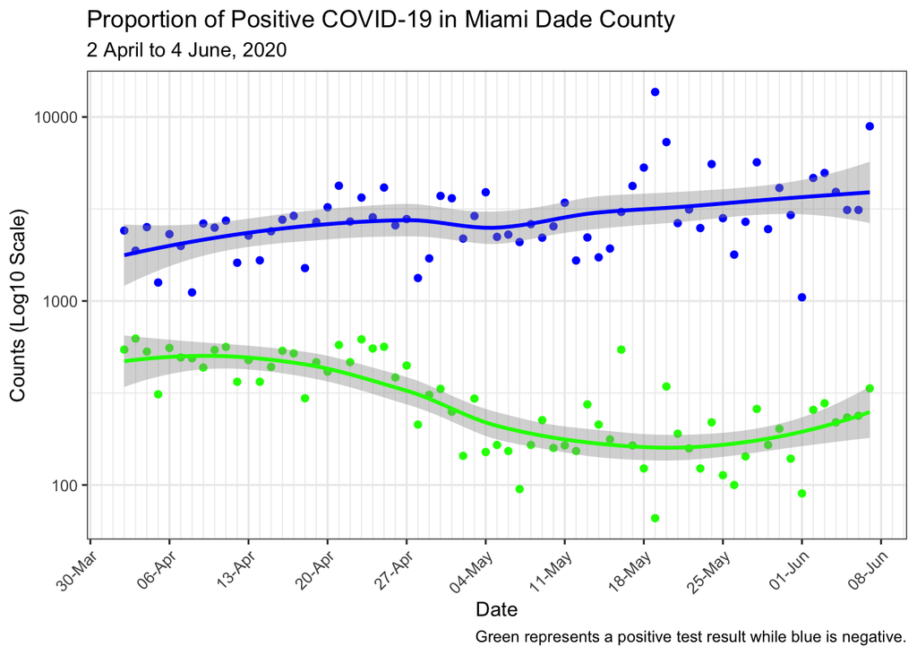

```r
ggplot(data = sflCases2_df) +

    theme_bw() +
    theme(axis.text.x = element_text(angle = 45, hjust = 1)) +
    aes(x = Date) +
    scale_x_date(
        date_breaks = "1 week",
        date_minor_breaks = "1 day",
        labels = scales::date_format("%d-%b")
    ) +
    scale_y_log10() +
    labs(
        title = "Proportion of Positive COVID-19 in Miami Dade County",
        subtitle = "2 April to 4 June, 2020",
        caption = "Green represents a positive test result while blue is negative.",
        y = "Counts (Log10 Scale)"
    ) +

    geom_point(aes(y = Positive), colour = "green") +
    stat_smooth(aes(y = Positive), method = "loess", colour = "green") +
  geom_point(aes(y = Negative), colour = "blue") +
    stat_smooth(aes(y = Negative), method = "loess", colour = "blue")
```

### Data Leading up to Making the Decision to Open

The proportion of positive tests over the two weeks before we decided to open the economy is (this is the data used to make the desicion to partially open the economy in Miami-Dade):

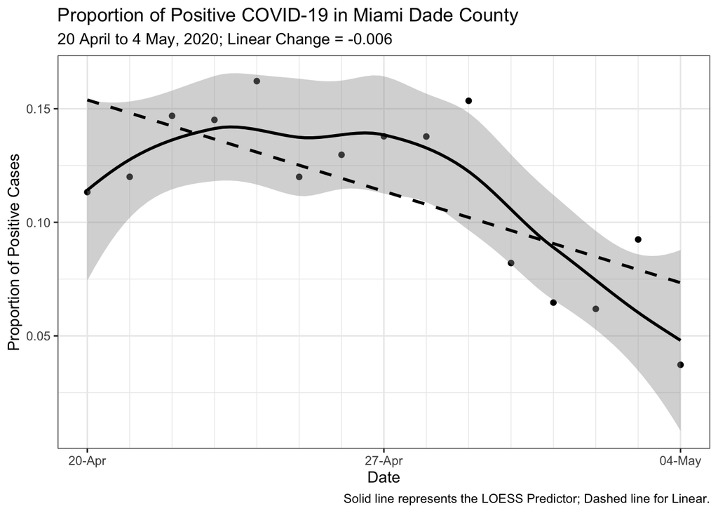

```r
# Linear Trend Slope
slope1 <- sflCases2_df %>%
    filter(Date > "2020-04-19") %>%
    filter(Date < "2020-05-05") %>%
    lm(PropPositive ~ Date, data = .) %>%
    coefficients() %>%
    pluck(2)

# Plot
ggplot(
    data = sflCases2_df %>%
        filter(Date > "2020-04-19") %>%
        filter(Date < "2020-05-05")
) +

    theme_bw() +
    aes(x = Date) +
    scale_x_date(
        date_breaks = "1 week",
        date_minor_breaks = "1 day",
        labels = scales::date_format("%d-%b")
    ) +
    labs(
        title = "Proportion of Positive COVID-19 in Miami Dade County",
        subtitle = paste(
            "20 April to 4 May, 2020; Linear Change =",
            round(slope1, 3)
        ),
        caption = "Solid line represents the LOESS Predictor; Dashed line for Linear.",
        y = "Proportion of Positive Cases"
    ) +

    geom_point(aes(y = PropPositive)) +
    stat_smooth(aes(y = PropPositive), method = "loess", colour = "black") +
    stat_smooth(
        aes(y = PropPositive),
        method = "lm",
        colour = "black",
        se = FALSE,
        linetype = "dashed"
    )
```

### Data Between Publicising the Decision to Open and Opening

The proportion of positive tests over the two weeks before we actually opened the economy is (this is what happened between when we decided to open the economy and declared it open):

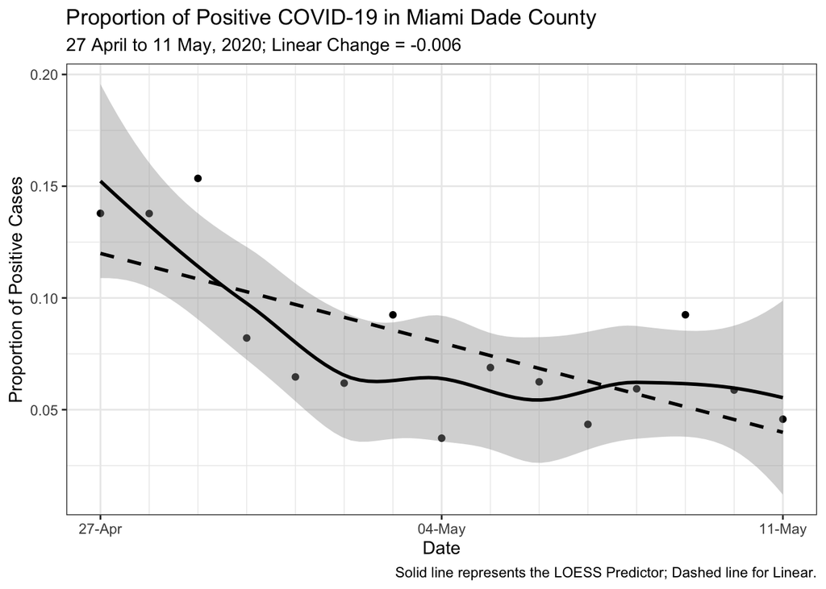

```r
# Linear Trend Slope
slope2 <- sflCases2_df %>%
    filter(Date > "2020-04-26") %>%
    filter(Date < "2020-05-12") %>%
    lm(PropPositive ~ Date, data = .) %>%
    coefficients() %>%
    pluck(2)

# Plot
ggplot(
    data = sflCases2_df %>%
        filter(Date > "2020-04-26") %>%
        filter(Date < "2020-05-12")
) +
    theme_bw() +
    aes(x = Date) +
    scale_x_date(
        date_breaks = "1 week",
        date_minor_breaks = "1 day",
        labels = scales::date_format("%d-%b")
    ) +
    labs(
        title = "Proportion of Positive COVID-19 in Miami Dade County",
        subtitle = paste(
            "27 April to 11 May, 2020; Linear Change =",
            round(slope2, 3)
        ),
        caption = "Solid line represents the LOESS Predictor; Dashed line for Linear.",
        y = "Proportion of Positive Cases"
    ) +
    geom_point(aes(y = PropPositive)) +
    stat_smooth(aes(y = PropPositive), method = "loess", colour = "black") +
    stat_smooth(
        aes(y = PropPositive),
        method = "lm",
        colour = "black",
        se = FALSE,
        linetype = "dashed"
    )
```

### Data During the Open Economy at First

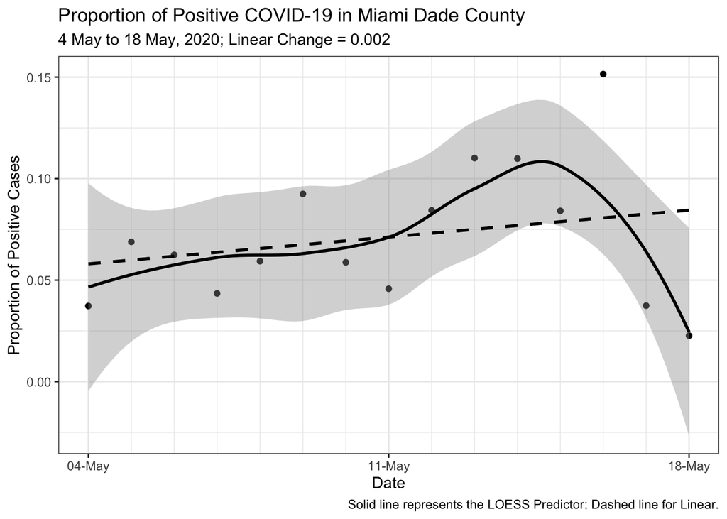

```r
# Linear Trend Slope
slope3 <- sflCases2_df %>%
        filter(Date > "2020-05-03") %>%
        filter(Date < "2020-05-19") %>%
    lm(PropPositive ~ Date, data = .) %>%
    coefficients() %>%
    pluck(2)

# Plot
ggplot(
    data = sflCases2_df %>%
        filter(Date > "2020-05-03") %>%
        filter(Date < "2020-05-19")
) +
    theme_bw() +
    aes(x = Date) +
    scale_x_date(
        date_breaks = "1 week",
        date_minor_breaks = "1 day",
        labels = scales::date_format("%d-%b")
    ) +
    labs(
        title = "Proportion of Positive COVID-19 in Miami Dade County",
        subtitle = paste(
            "4 May to 18 May, 2020; Linear Change =",
            round(slope3, 3)
        ),
        caption = "Solid line represents the LOESS Predictor; Dashed line for Linear.",
        y = "Proportion of Positive Cases"
    ) +
    geom_point(aes(y = PropPositive)) +
    stat_smooth(aes(y = PropPositive), method = "loess", colour = "black") +
    stat_smooth(
        aes(y = PropPositive),
        method = "lm",
        colour = "black",
        se = FALSE,
        linetype = "dashed"
    )
```

### Data During Mid-May

The proportion of positive tests for the middle two weeks of May is:

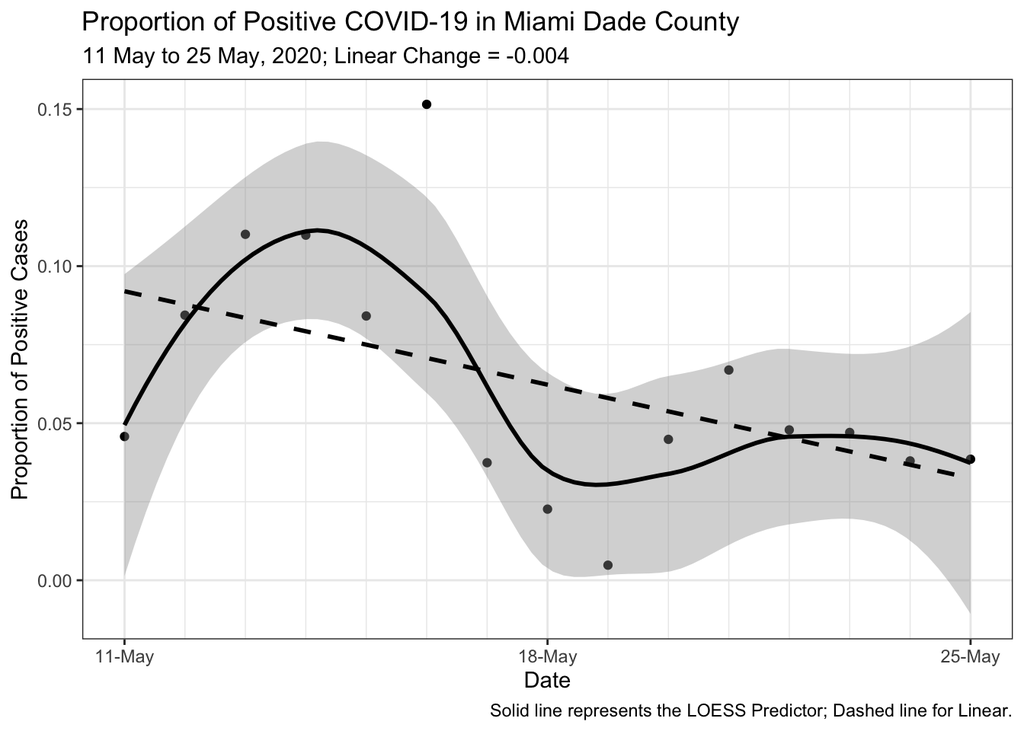

```r
# Linear Trend Slope
slope4 <- sflCases2_df %>%
        filter(Date > "2020-05-10") %>%
        filter(Date < "2020-05-26") %>%
    lm(PropPositive ~ Date, data = .) %>%
    coefficients() %>%
    pluck(2)

# Plot
ggplot(
    data = sflCases2_df %>%
        filter(Date > "2020-05-10") %>%
        filter(Date < "2020-05-26")
) +
    theme_bw() +
    aes(x = Date) +
    scale_x_date(
        date_breaks = "1 week",
        date_minor_breaks = "1 day",
        labels = scales::date_format("%d-%b")
    ) +
    labs(
        title = "Proportion of Positive COVID-19 in Miami Dade County",
        subtitle = paste(
            "11 May to 25 May, 2020; Linear Change =",
            round(slope4, 3)
        ),
        caption = "Solid line represents the LOESS Predictor; Dashed line for Linear.",
        y = "Proportion of Positive Cases"
    ) +
    geom_point(aes(y = PropPositive)) +
    stat_smooth(aes(y = PropPositive), method = "loess", colour = "black") +
    stat_smooth(
        aes(y = PropPositive),
        method = "lm",
        colour = "black",
        se = FALSE,
        linetype = "dashed"
    )
```

### Data During Last Two Weeks of May

The proportion of positive tests for the last two weeks of May is:

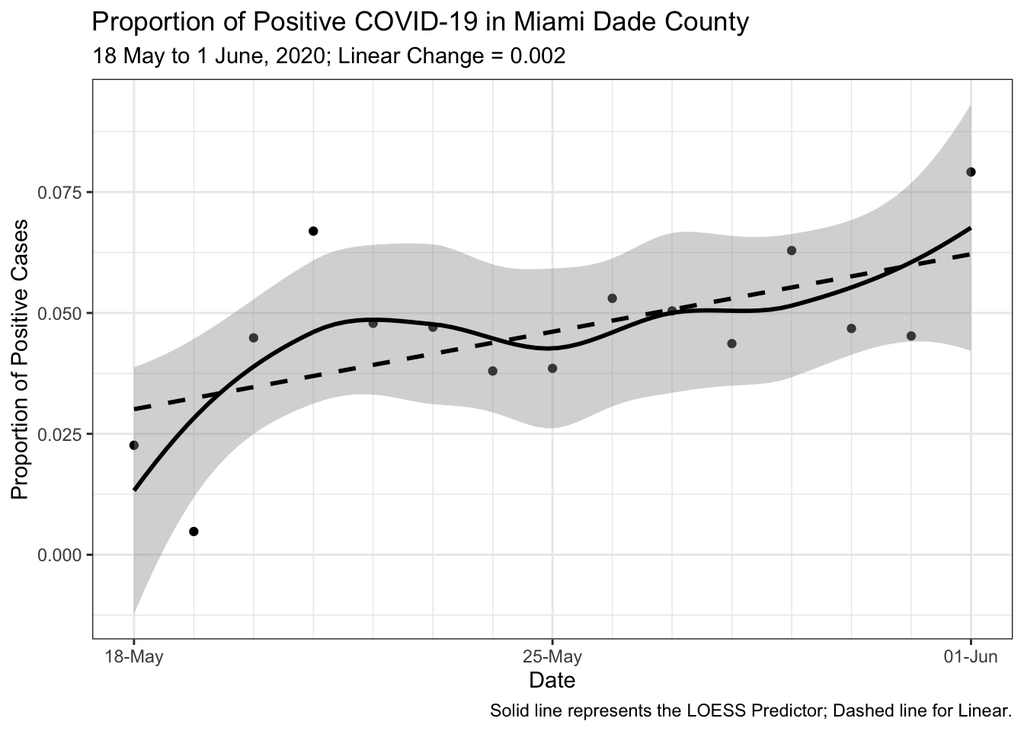

```r
# Linear Trend Slope
slope5 <- sflCases2_df %>%
        filter(Date > "2020-05-17") %>%
        filter(Date < "2020-06-02") %>%
    lm(PropPositive ~ Date, data = .) %>%
    coefficients() %>%
    pluck(2)

# Plot
ggplot(
    data = sflCases2_df %>%
        filter(Date > "2020-05-17") %>%
        filter(Date < "2020-06-02")
) +
    theme_bw() +
    aes(x = Date) +
    scale_x_date(
        date_breaks = "1 week",
        date_minor_breaks = "1 day",
        labels = scales::date_format("%d-%b")
    ) +
    labs(
        title = "Proportion of Positive COVID-19 in Miami Dade County",
        subtitle = paste(
            "18 May to 1 June, 2020; Linear Change =",
            round(slope5, 3)
        ),
        caption = "Solid line represents the LOESS Predictor; Dashed line for Linear.",
        y = "Proportion of Positive Cases"
    ) +
    geom_point(aes(y = PropPositive)) +
    stat_smooth(aes(y = PropPositive), method = "loess", colour = "black") +
    stat_smooth(
        aes(y = PropPositive),
        method = "lm",
        colour = "black",
        se = FALSE,
        linetype = "dashed"
    )
```

### Data During May-June Transition

The proportion of positive tests for the last week of May and first week of June is:

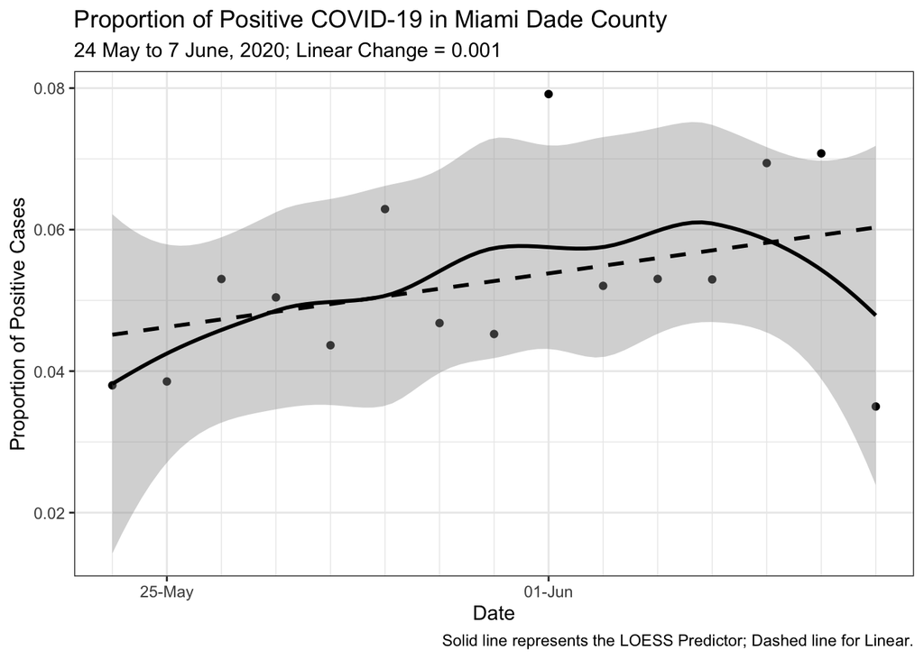

```r
# Linear Trend Slope
slope6 <- sflCases2_df %>%
        filter(Date > "2020-05-23") %>%
        filter(Date < "2020-06-08") %>%
    lm(PropPositive ~ Date, data = .) %>%
    coefficients() %>%
    pluck(2)

# Plot
ggplot(
    data = sflCases2_df %>%
        filter(Date > "2020-05-23") %>%
        filter(Date < "2020-06-08")
) +
    theme_bw() +
    aes(x = Date) +
    scale_x_date(
        date_breaks = "1 week",
        date_minor_breaks = "1 day",
        labels = scales::date_format("%d-%b")
    ) +
    labs(
        title = "Proportion of Positive COVID-19 in Miami Dade County",
        subtitle = paste(
            "24 May to 7 June, 2020; Linear Change =",
            round(slope6, 3)
        ),
        caption = "Solid line represents the LOESS Predictor; Dashed line for Linear.",
        y = "Proportion of Positive Cases"
    ) +
    geom_point(aes(y = PropPositive)) +
    stat_smooth(aes(y = PropPositive), method = "loess", colour = "black") +
    stat_smooth(
        aes(y = PropPositive),
        method = "lm",
        colour = "black",
        se = FALSE,
        linetype = "dashed"
    )
```

### Full Data

These are the proportions of positive tests for the full data.

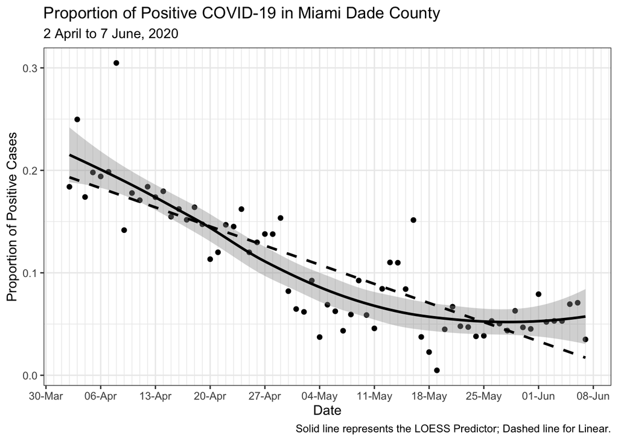

```r
ggplot(data = sflCases2_df) +

    theme_bw() +
    aes(x = Date) +
    scale_x_date(
        date_breaks = "1 week",
        date_minor_breaks = "1 day",
        labels = scales::date_format("%d-%b")
    ) +
    labs(
        title = "Proportion of Positive COVID-19 in Miami Dade County",
        subtitle = "2 April to 7 June, 2020",
        caption = "Solid line represents the LOESS Predictor; Dashed line for Linear.",
        y = "Proportion of Positive Cases"
    ) +

    geom_point(aes(y = PropPositive)) +
    stat_smooth(aes(y = PropPositive), method = "loess", colour = "black") +
    stat_smooth(
        aes(y = PropPositive),
        method = "lm",
        colour = "black",
        se = FALSE,
        linetype = "dashed"
    )
```

## Hospitalisation Data

```r
library(readxl)
data_dir <- "../../data/"
dataFiles_char <- list.files(path = data_dir, pattern = "ESS_.*hrs")

read_excel_safely <- safely(read_excel)

miamidadeHospitalised_ls <-
    map(
        .x = dataFiles_char,
        .f = ~{

        df_ls <- read_excel_safely(
          path = paste0(data_dir, .x),
        sheet = ifelse(
            # The tab name changed in June (06)
            test = str_detect(.x, pattern = "Hospitals_06"),
            yes = "County_Bed_Avail_Report_for_Par",
            no = "County_Bed_Availability_Report_"
        ),
        skip = 1
      )

        if(is.null(df_ls$error)){

            df_ls$result %>%
            filter(County == "MIAMI-DADE") %>%
            select(contains("COVID")) %>%
            mutate(
                Date_char = str_remove(
                    .x,
                    pattern = "ESS_BedAvailabilityWithAddlinfo_Hospitals_"
                )
            ) %>%
            mutate(
                Date_char = str_sub(Date_char, end = 10)
            ) %>%
            mutate(
                Date_char = str_replace_all(
                    Date_char,
                    pattern = "\\.",
                    replacement = "-"
                )
            ) %>%
            mutate(Date = as.POSIXct(Date_char, format = "%m-%d-%Y")) %>%
            select(-Date_char) %>%
            select(Date, everything())

        } else {
            NULL
        }

        }
    )

# We had a data wrangling error, so I wrapped read_excel() in a safely() and
#   added an if() statement.
miamidadeHospitalised_ls %>%
    map_lgl(is.null) %>%
    which()
```

```
## [1] 30
```

```r
# 30 83 84 85 86 87
# dataFiles_char[30]
# "ESS_BedAvailabilityWithAddlinfo_Hospitals_04.23.2020_1045hrs.xlsx"
# I inspected this file manually and found the sheet's name was abbreviated
miamidadeHospitalised_ls[[30]] <-
    read_excel(
    path = paste0(data_dir, dataFiles_char[30]),
    sheet = "County",
    skip = 1
  ) %>%
  filter(County == "MIAMI-DADE") %>%
  select(contains("COVID")) %>%
  mutate(Date_char = "2020-04-23") %>%
  mutate(Date = as.POSIXct(Date_char, format = "%Y-%m-%d")) %>%
  select(-Date_char) %>%
  select(Date, everything())

# dataFiles_char[83]
# After June 1, they changed the sheet name.
# miamidadeHospitalised_ls[[83]]


miamidadeHospitalised_df <-
    miamidadeHospitalised_ls %>%
    bind_rows() %>%
    mutate(Hospitalised = `COVID IN ICU` + `COVID NON ICU`) %>%
  rename(
    ICU = `COVID IN ICU`,
    Ventilated = `COVID ON VENT`,
    AdmitPrevDay = `COVID + Admits Day Before`,
    DischPrevDay = `COVID + Disch Day Before`
  ) %>%
    mutate(DeltaAdmit = AdmitPrevDay - DischPrevDay) %>%
  select(
    Date, Hospitalised, ICU, Ventilated, AdmitPrevDay, DischPrevDay, DeltaAdmit
  )
```

```r
knitr::kable(miamidadeHospitalised_df)
```

| Date | Hospitalised | ICU | Ventilated | AdmitPrevDay | DischPrevDay | DeltaAdmit |
| --- | --- | --- | --- | --- | --- | --- |
| 2020-04-02 | 320 | 130 | 116 | NA | NA | NA |
| 2020-04-03 | 346 | 133 | 116 | 111 | 33 | 78 |
| 2020-04-04 | 416 | 133 | 112 | 59 | 37 | 22 |
| 2020-04-05 | 533 | 188 | 146 | 108 | 19 | 89 |
| 2020-04-06 | 516 | 178 | 151 | 89 | 21 | 68 |
| 2020-04-07 | 591 | 199 | 167 | 76 | 28 | 48 |
| 2020-04-08 | 636 | 215 | 166 | 107 | 32 | 75 |
| 2020-04-09 | 634 | 232 | 170 | 99 | 61 | 38 |
| 2020-04-10 | 681 | 245 | 172 | 79 | 37 | 42 |
| 2020-04-10 | 676 | 251 | 183 | 73 | 36 | 37 |
| 2020-04-11 | 671 | 238 | 177 | 99 | 64 | 35 |
| 2020-04-12 | 672 | 243 | 192 | 80 | 59 | 21 |
| 2020-04-12 | 714 | 245 | 183 | 60 | 61 | -1 |
| 2020-04-13 | 653 | 247 | 184 | 74 | 47 | 27 |
| 2020-04-13 | 695 | 251 | 184 | 80 | 48 | 32 |
| 2020-04-14 | 653 | 204 | 146 | 69 | 41 | 28 |
| 2020-04-14 | 712 | 249 | 174 | 86 | 66 | 20 |
| 2020-04-15 | 693 | 234 | 169 | 84 | 76 | 8 |
| 2020-04-16 | 714 | 223 | 176 | 77 | 84 | -7 |
| 2020-04-16 | 736 | 226 | 176 | 74 | 111 | -37 |
| 2020-04-17 | 706 | 213 | 172 | 83 | 107 | -24 |
| 2020-04-17 | 797 | 285 | 170 | 74 | 88 | -14 |
| 2020-04-18 | 697 | 221 | 170 | 101 | 137 | -36 |
| 2020-04-18 | 697 | 219 | 170 | 93 | 138 | -45 |
| 2020-04-19 | 730 | 223 | 170 | 71 | 105 | -34 |
| 2020-04-20 | 727 | 210 | 167 | 58 | 64 | -6 |
| 2020-04-21 | 759 | 205 | 155 | 92 | 81 | 11 |
| 2020-04-22 | 743 | 196 | 148 | 72 | 88 | -16 |
| 2020-04-22 | 722 | 194 | 139 | 71 | 121 | -50 |
| 2020-04-23 | 706 | 186 | 129 | 91 | 62 | 29 |

[output cut: 57 more lines]

```r
mdCOVID_df <-
    miamidadeHospitalised_df %>%
    pivot_longer(
        Hospitalised:DeltaAdmit,
        names_to = "Type",
        values_to = "Count"
    )
```

### Hosptial COVID-19 Census

Census plot of hospitalisations, patients in ICU, and those in ICU on ventilators.

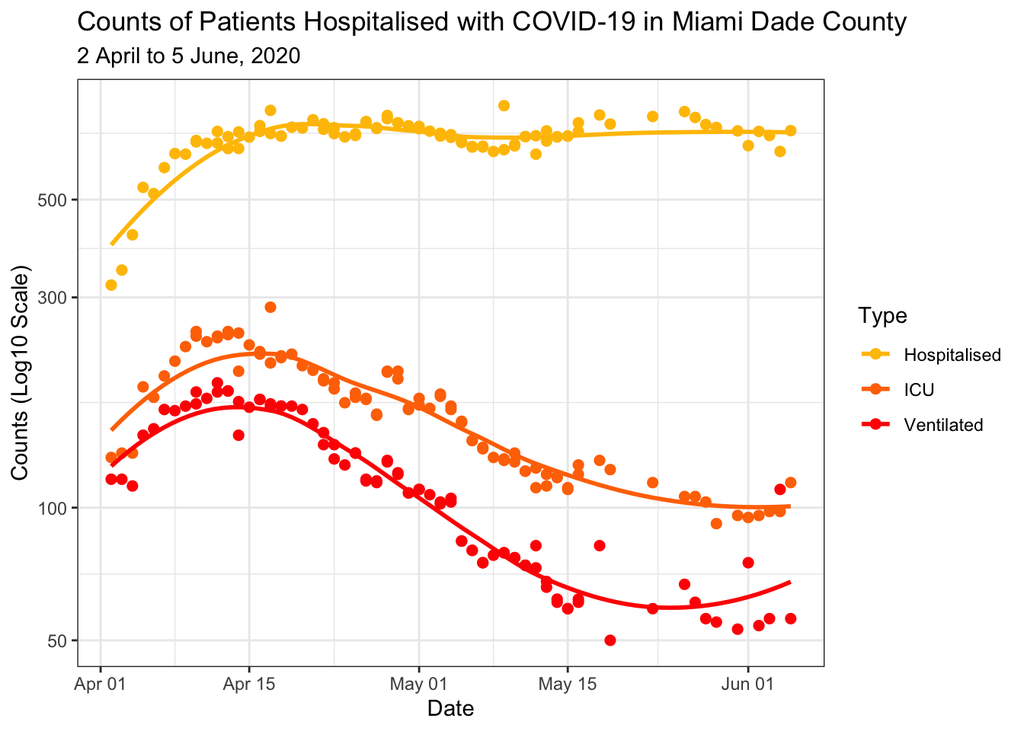

```r
ggplot(
    data = mdCOVID_df %>%
        filter(Type != "DischPrevDay") %>%
        filter(Type != "AdmitPrevDay") %>%
        filter(Type != "DeltaAdmit")
) +

    theme_bw() +
    aes(x = Date, y = Count, group = Type, colour = Type) +
    scale_color_manual(
        values = c(
            "Ventilated" = "#ff0000",
            "ICU" = "#ff7400",
            "Hospitalised" = "#ffc100",
            "AdmitPrevDay" = "black"
        )
    ) +
    scale_y_log10() +
    labs(
        title = "Counts of Patients Hospitalised with COVID-19 in Miami Dade County",
        subtitle = "2 April to 5 June, 2020",
        y = "Counts (Log10 Scale)"
    ) +

    geom_point(size = 2) +
    stat_smooth(se = FALSE)
```

### Net Hospital Admissions

#### Net New Admissions

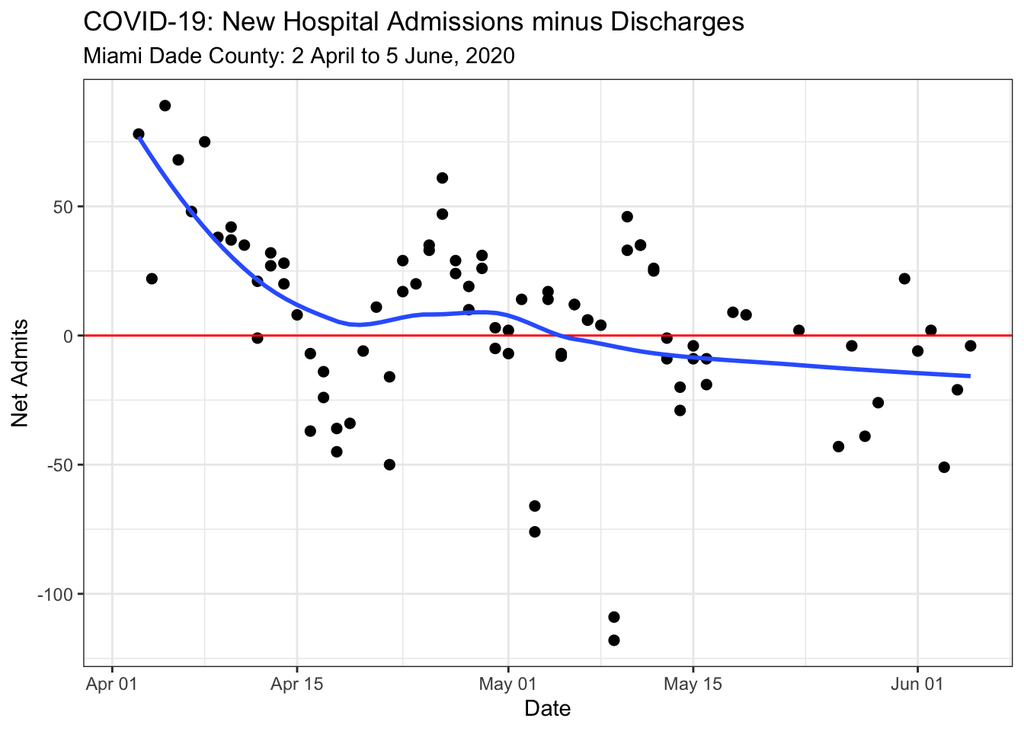

```r
ggplot(
    data = mdCOVID_df %>%
        filter(Type == "DeltaAdmit")
) +

    theme_bw() +
    aes(x = Date, y = Count) +
    labs(
        title = "COVID-19: New Hospital Admissions minus Discharges",
        subtitle = "Miami Dade County: 2 April to 5 June, 2020",
        y = "Net Admits"
    ) +

    geom_point(size = 2) +
    geom_hline(yintercept = 0, colour = "red") +
    stat_smooth(se = FALSE)
```

#### Admissions vs Dicharges

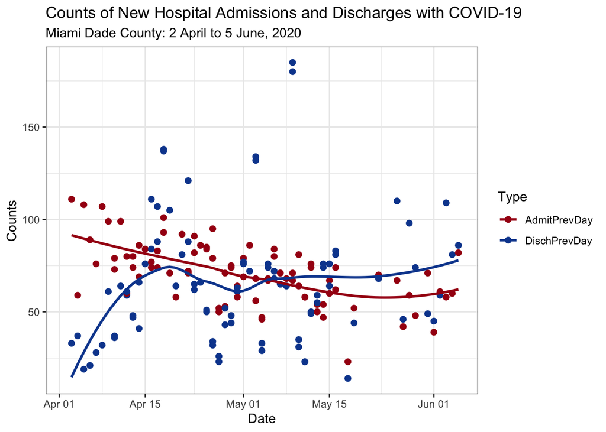

```r
ggplot(
    data = mdCOVID_df %>%
        filter(Type %in% c("DischPrevDay", "AdmitPrevDay"))
) +

    theme_bw() +
    aes(x = Date, y = Count, group = Type, colour = Type) +
    scale_color_manual(
        values = c(
            "AdmitPrevDay" = "#a61414",
            "DischPrevDay" = "#0C479D"
        )
    ) +
    labs(
        title = "Counts of New Hospital Admissions and Discharges with COVID-19",
        subtitle = "Miami Dade County: 2 April to 5 June, 2020",
        y = "Counts"
    ) +

    geom_point(size = 2) +
    stat_smooth(se = FALSE)
```